# data609hw6

jim lung

October 4, 2018

**251**

2. A rancher has determined that the minimum weekly nutritional requirements for an average-sized horse include 40lb of protein, 20lb of carbohydrates, and 45lb of roughage. These are obtained from the following sources in varying amounts at the prices indicated:

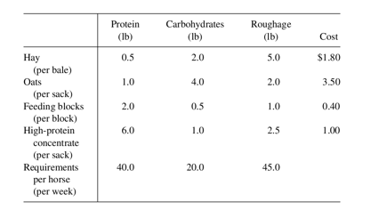

table

Formulate a mathematical model to determine how to meet the minimum nutritional requirements at minimum cost.

Amounts of all the different feed types are paramaters in the model.

Minimize $Cost(H, T, F, P) = 1.8H + 3.5T + 0.4F + 1.0P$

This is subjec to following:

Protein: $0.5H + 1.0T + 2.0F + 6.0P >= 40.0$

Carbs: $2.0H + 4.0T + 0.5F + 1.0P >= 20.0$

$H,T,F,P >=0$

**264**

6. Use graphical analysis to Maximize 10x + 35y subject to:

8x + 6y <= 48 (board-feet of lumber)

4x = y <= 20 (hours of carpentry)

y >= 5 (demand)

x,y, >= 0 (nonnegativity)

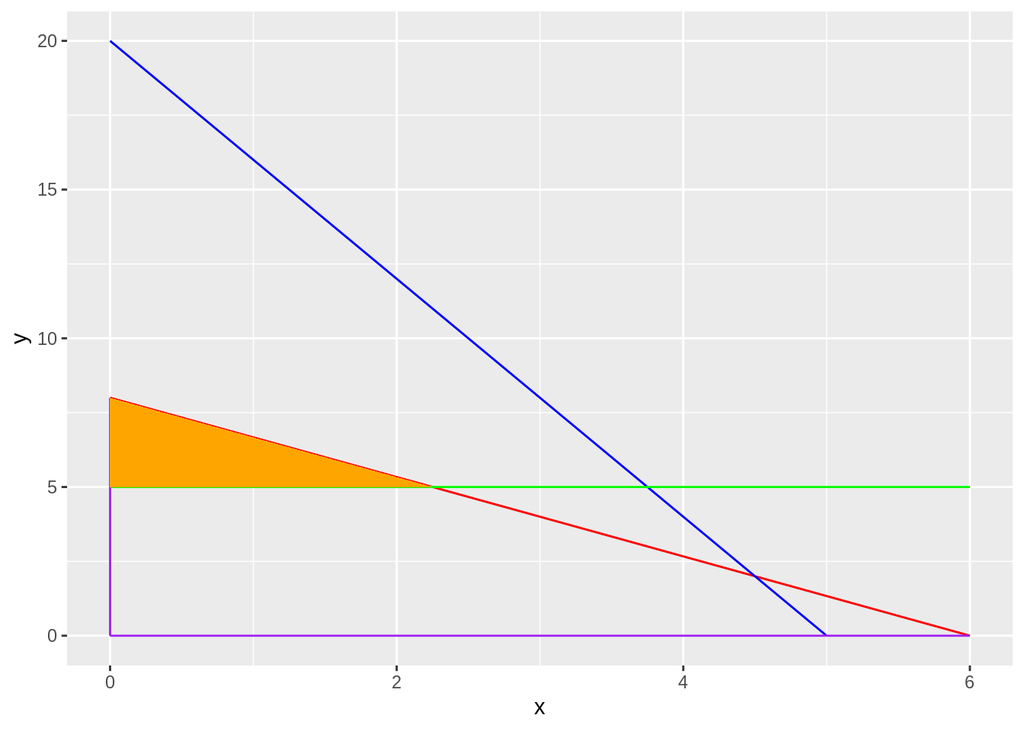

```r
library(ggplot2)

dfC1 <- data.frame(x=c(0,6), y=c(8,0))
dfC2 <- data.frame(x=c(0,5), y=c(20,0))
dfC3 <- data.frame(x=c(0,6), y=c(5,5))
dfC4x <- data.frame(x=c(0,0), y=c(0,8))
dfC4y <- data.frame(x=c(0,6), y=c(0,0))
region <- data.frame(x=c(0, 0, 2.25), y=c(5, 8, 5))

g1 <- ggplot() + geom_line(data=dfC1, aes(x=x, y=y), colour="red") +
  geom_line(data=dfC2, aes(x=x, y=y), colour="blue") +
  geom_line(data=dfC3, aes(x=x, y=y), colour="green") +
  geom_line(data=dfC4x, aes(x=x, y=y), colour="purple") +
  geom_line(data=dfC4y, aes(x=x, y=y), colour="purple") +
  geom_polygon(data=region, aes(x=x, y=y), fill="orange")

g1
```

The extreme points are:

The intersection of constraint 1 and 5 at point (0,8)

The intersection of constraint 1 and 3 at point (2.25, 5)

The intersection of constraint 3 and 5 at point (0,5)

Plug them into the objective equation : $(10 * x) + (35 * y)$ to find the maximum which is *(0,8) with value of 280.0.*

**268**

6. Using the method in section 7.3, Maximize 10x + 35y subject to:

8x + 6y <= 48 (board-feet of lumber)

4x + y <= 20 (hours of carpentry)

y >= 5 (demand)

x,y, >= 0 (nonnegativity)

*Decision Variables to format xi*

8x1 + 6x2 <= 48 (board-feet of lumber)

4x1 + x2 <= 20 (hours of carpentry)

x2 >= 5 (demand)

x1,x2 >= 0 (nonnegativity)

*Add yi variables*

8x1 + 6x2 + y1 = 48 (board-feet of lumber)

4x1 + x2 + y2 = 20 (hours of carpentry)

x2 = 5 + y3(demand)

x1,x2, y1, y2, y3 >= 0 (nonnegativity)

Iterate through the variable combinations, set 4x1 + x2 + y2 = 20 to 0.

x1,x2 = 0, x2 violates constraint 3

when x1,y1 = 0

6x2 = 48 (board-feet of lumber)

x2 + y2 = 20 (hours of carpentry)

x2 = 5 + y3 (demand)

Results:

x2 = 8 y2 = 12 y3 = 3

*The feasible point at (0,8)*

When x1, y2 = 0

6x2 + y1 = 48

x2 = 20

x2 = 5

*Solution is not possible, negative*

When x1,y3=0

6x2 + y1 = 48

x2 + y2 = 20

x2 = 5

Results:

x2 = 5 y2 = 15 y1 = 18

*Feasible points at (0,5)*

x2,y1 = 0, constraint 3 is violated

y1,y2 = 0. consraint 3 is violated

When y1,y3 = 0

8x1 + 6x2 = 48

4x1 + x2 + y2 =20

x2 = 5

Results:

x2= 5 x1 = 2.25 y2=6

*Feasible points at (2.25,5)*

When y2,y3 = 0

8x1 + 6x2 + y1 = 48

4x1 + x2 = 20

x2 = 5

Results:

x2 = 5 x1 = 3.75 y1 = -12

*Solution is not possible, negative*

Enter three possible solutions into $(10 * x) + (35 * y)$

Get the same answer, find the maximum which is *(0,8) with value of 280.0.*